# Exploring Mental Health Data (Kaggle)

### Model Evaluation

**Metrics are not definitive! Only one train-test split has been evaluated.**

- model achieves reasonable accuracy! kappa score indicates its better than chance
- predicted probabilities for incorrect predictions are not far from `0.5` threshold, and correct predictions are more confident
- balanced precision and recall
  - could make case that a model should be optimized for recall, as *minimizing* false negatives could be more important for treatment distribution. in other words, assuming a support based treatment, false positives may not be as detrimental as missing those with depression
- ROC and Precision-Recall curves presented without discussion, will overlay results from the next model in the following section

**Prediction Probability Distributions**

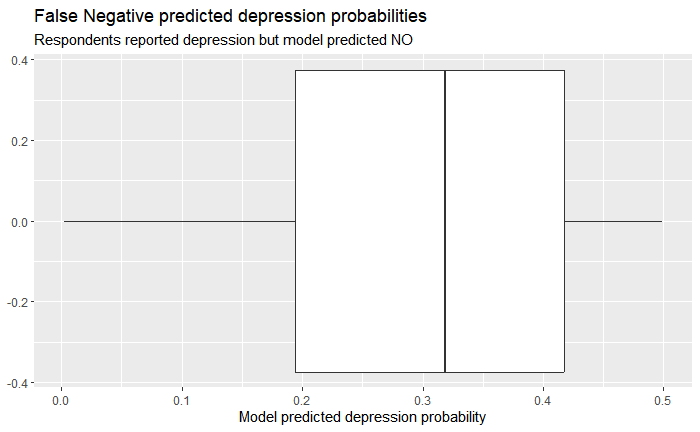

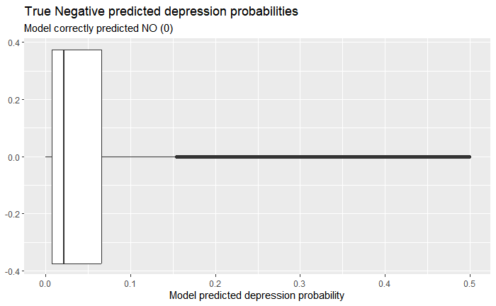

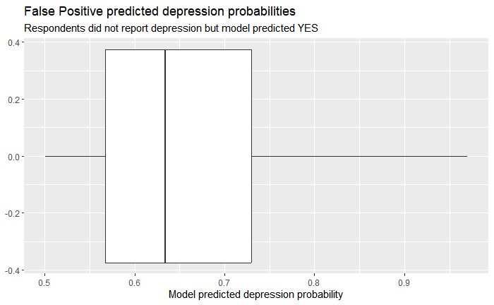

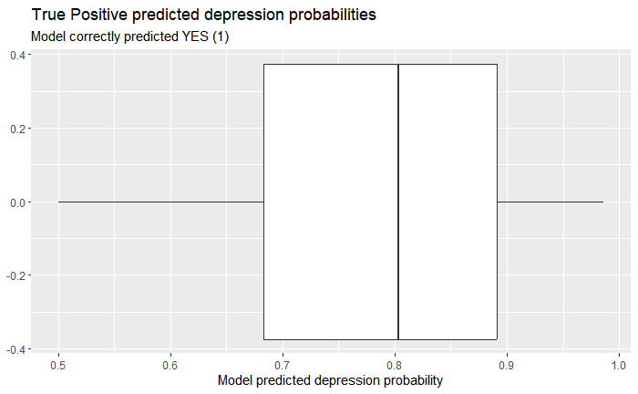

**Model Metrics**

```r
# data, truth, estimate
scores <- accuracy(results, truth = Depression, estimate = .pred_class)

scores <- scores %>% add_row(
  precision(results, truth = Depression, estimate = .pred_class)
)
scores <- scores %>% add_row(
  recall(results, truth = Depression, estimate = .pred_class)
)
scores <- scores %>% add_row(
  kap(results, truth = Depression, estimate = .pred_class)
)
scores <- scores %>% add_row(
  roc_auc(results, Depression, .pred_0)
)
scores
```

| .metric | .estimator | .estimate |
| --- | --- | --- |
| accuracy | binary | 0.9350756 |
| precision | binary | 0.9472729 |
| recall | binary | 0.9749305 |
| kap | binary | 0.7698515 |
| roc_auc | binary | 0.9719290 |

```r
cmat <- conf_mat(results, Depression, .pred_class)
cmat
```

```
          Truth
Prediction     0     1
         0 22439  1249
         1   577  3860
```

```r
summary(cmat)
```

| .metric | .estimator | .estimate |
| --- | --- | --- |
| accuracy | binary | 0.9350756 |
| kap | binary | 0.7698515 |
| sens | binary | 0.9749305 |
| spec | binary | 0.7555295 |
| ppv | binary | 0.9472729 |
| npv | binary | 0.8699572 |
| mcc | binary | 0.7726279 |
| j_index | binary | 0.7304599 |
| bal_accuracy | binary | 0.8652300 |
| detection_prevalence | binary | 0.8422400 |

[output cut: 3 more lines]

**Receiver Operating Characteristic and Precision-Recall Curves**

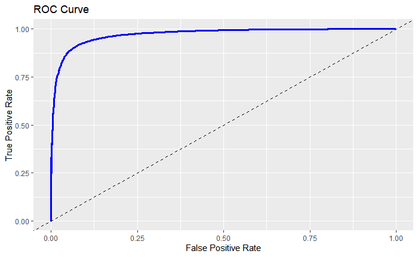

```r
roc_c <- roc_curve(results, Depression, .pred_0)

ggplot(roc_c,
       aes(x=1-specificity, y=sensitivity)) +
  geom_line(color="blue", linewidth=1.2) +
  # geom_segment(aes(x=0, xend=1, y=0, yend=1), linetype=2) +
  geom_abline(linetype=2, ) +
  labs(title = "ROC Curve") + xlab("False Positive Rate") +
  ylab("True Positive Rate")
```

```r
slice_sample(roc_c, n=10) %>% arrange(.threshold)
```

| .threshold | specificity | sensitivity |
| --- | --- | --- |
| 0.02980529 | 0.01115678 | 1.00000000 |
| 0.43596233 | 0.70091995 | 0.98075252 |
| 0.61842023 | 0.83969466 | 0.95768161 |
| 0.87608413 | 0.96515952 | 0.83672228 |
| 0.90044659 | 0.97220591 | 0.80291971 |
| 0.94004189 | 0.98649442 | 0.71011470 |
| 0.96090685 | 0.99099628 | 0.61935176 |
| 0.99112288 | 0.99921707 | 0.26924748 |
| 0.99507394 | 0.99941280 | 0.15358881 |
| 0.99847523 | 1.00000000 | 0.02906674 |

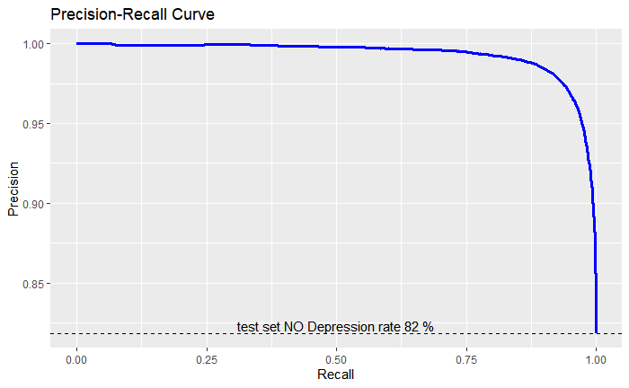

```r
pr_c <- pr_curve(results, Depression, .pred_0)

base_rate <- 1-(sum(as.numeric(test$Depression)-1)/dim(test)[1])

ggplot(pr_c,
       aes(x=recall, y=precision)) +
  geom_line(color="blue", linewidth=1.2) +
  geom_hline(yintercept=base_rate, linetype=2) +
  annotate("text", x=0.5, y=base_rate+.005,
           label=paste("test set NO Depression rate", 100*round(base_rate,2),
                       "%")) +
  labs(title = "Precision-Recall Curve") +
  xlab("Recall") +
  ylab("Precision")
```

```r
slice_sample(pr_c, n=10) %>% arrange(.threshold)
```

| .threshold | recall | precision |
| --- | --- | --- |
| 0.3626123 | 0.98766076 | 0.9218915 |
| 0.7356926 | 0.92618179 | 0.9780684 |
| 0.8422687 | 0.86904762 | 0.9885830 |
| 0.9286156 | 0.74469934 | 0.9949498 |
| 0.9334723 | 0.73205596 | 0.9953332 |
| 0.9833886 | 0.42031630 | 0.9985549 |
| 0.9842685 | 0.40450122 | 0.9984985 |
| 0.9898229 | 0.30066041 | 0.9994223 |
| 0.9944165 | 0.17596455 | 0.9990133 |
| 0.9983485 | 0.03345499 | 1.0000000 |

### Comparison to GLM engine

- model handles one-hot-encoded binary features differently, only uses one of two
  - *Gender, Student vs Professional*
- overall similar feature importances, opposite intercept
- *metrics compared directly in section below*

```r
# Define and fit model
model2 <- logistic_reg(engine = "glm", mode="classification") %>%
  fit(Depression ~ ., data = train)

tidy(model2)
```

| term | estimate | std.error | statistic | p.value |
| --- | --- | --- | --- | --- |
| (Intercept) | 1.00896769 | 0.092764209 | 10.8766915 | 1.488686e-27 |
| Gender_M | 0.01137094 | 0.027890002 | 0.4077068 | 6.834890e-01 |
| Gender_F | NA | NA | NA | NA |
| Age | -0.16821862 | 0.001794404 | -93.7462444 | 0.000000e+00 |
| Professional | -1.94057323 | 0.031857374 | -60.9144127 | 0.000000e+00 |
| Student | NA | NA | NA | NA |
| Suicidal_Thoughts | 2.48361307 | 0.032352021 | 76.7684064 | 0.000000e+00 |
| Family_History | 0.22965846 | 0.027737709 | 8.2796479 | 1.235400e-16 |
| Work_Study_Hours | 0.13224662 | 0.003766832 | 35.1081828 | 5.056579e-270 |
| Financial_Stress | 0.55252498 | 0.010331957 | 53.4772850 | 0.000000e+00 |

[output cut: 4 more lines]

```r
extract_spec_parsnip(model2)
```

```
Logistic Regression Model Specification (classification)

Computational engine: glm

Model fit template:
stats::glm(formula = missing_arg(), data = missing_arg(), weights = missing_arg(),
    family = stats::binomial)
```

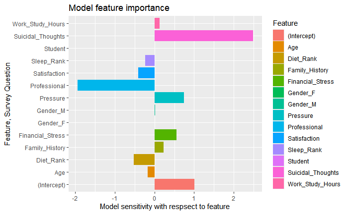

```r
# Feature Importance Plot
coeff2 <- tidy(model2) %>%
  arrange(desc(abs(estimate)))

ggplot(coeff2, aes(y = term, x = estimate, fill = term)) + geom_col() +
  labs(title="Model feature importance",  fill="Feature") +
  xlab("Model sensitivity with respsect to feature") +
  ylab("Feature, Survey Question")
```

```r
# Predictions
pred_y2 <- predict(model2, test,
                      type = "class")

pred_proba2 <- predict(model2, test,
                      type = "prob")

results2 <- test %>%
           select(Depression) %>%
           bind_cols(pred_y2, pred_proba2)


# metrics
scores2 <- accuracy(results2, truth = Depression, estimate = .pred_class)

scores2 <- scores2 %>% add_row(
  precision(results2, truth = Depression, estimate = .pred_class)
)

scores2 <- scores2 %>% add_row(
  recall(results2, truth = Depression, estimate = .pred_class)
)

scores2 <- scores2 %>% add_row(
  kap(results2, truth = Depression, estimate = .pred_class)
)

scores2 <- scores2 %>% add_row(
  roc_auc(results2, Depression, .pred_0)
)

scores2
```

| .metric | .estimator | .estimate |
| --- | --- | --- |
| accuracy | binary | 0.9382044 |
| precision | binary | 0.9570017 |
| recall | binary | 0.9679788 |
| kap | binary | 0.7878879 |
| roc_auc | binary | 0.9729324 |

```r
cmat2 <- conf_mat(results2, Depression, .pred_class)
cmat2
```

```
          Truth
Prediction     0     1
         0 22279  1001
         1   737  4108
```

```r
summary(cmat2)
```

| .metric | .estimator | .estimate |
| --- | --- | --- |
| accuracy | binary | 0.9382044 |
| kap | binary | 0.7878879 |
| sens | binary | 0.9679788 |
| spec | binary | 0.8040712 |
| ppv | binary | 0.9570017 |
| npv | binary | 0.8478844 |
| mcc | binary | 0.7882971 |
| j_index | binary | 0.7720500 |
| bal_accuracy | binary | 0.8860250 |
| detection_prevalence | binary | 0.8277333 |

[output cut: 3 more lines]

### Direct Comparison

- similar performance in terms of accuracy, higher precision and lower recall
  - as discussed, this might be worse, depending on desired application of model. however differences are slight
- might expect bigger changes to original model performance by altering `glmnet` hyperparameters

```r
comparison <- select(scores, .metric)
comparison["glmnet"] <- select(scores, .estimate)
comparison["glm"] <- select(scores2, .estimate)
comparison
```

| .metric | glmnet | glm |
| --- | --- | --- |
| accuracy | 0.9350756 | 0.9382044 |
| precision | 0.9472729 | 0.9570017 |
| recall | 0.9749305 | 0.9679788 |
| kap | 0.7698515 | 0.7878879 |
| roc_auc | 0.9719290 | 0.9729324 |

```r
roc_c2 <- roc_curve(results2, Depression, .pred_0)
pr_c2 <- pr_curve(results2, Depression, .pred_0)
roc_c["spec2"] <- roc_c2["specificity"]
roc_c["sens2"] <- roc_c2["sensitivity"]
pr_c["recall2"] <- pr_c2["recall"]
pr_c["precision2"] <- pr_c2["precision"]
```

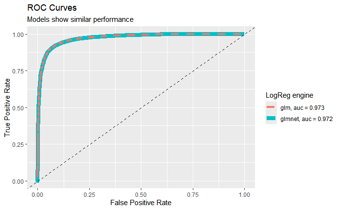

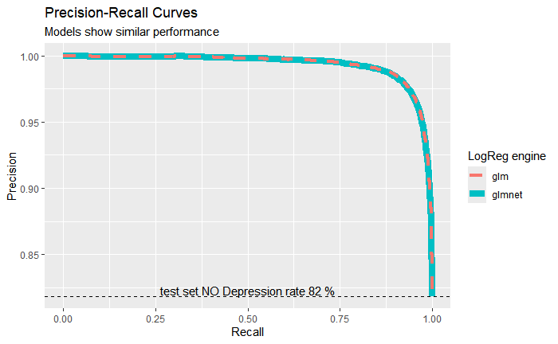